# Tugas 5 MPDW (Pemeriksaan Stasioneritas Data)

Alfiah Ayu Hapsari (G1401211063)

2023-09-23

```r
library(ggplot2)
library(tsibble)
library(tseries)
library(MASS)
```

### Input Data

```r
library(rio)
data <- import("https://raw.githubusercontent.com/alfiahayu/mpdw/main/Data/data%20mpdw.csv")
head(data)
```

```
##      Periode Harga
## 1 2021-01-03 14500
## 2 2021-01-10 14500
## 3 2021-01-17 14500
## 4 2021-01-24 14500
## 5 2021-01-31 14500
## 6 2021-02-07 14550
```

```r
data <- data$Harga
data.ts <- ts(data)
```

### Plot *Time Series*

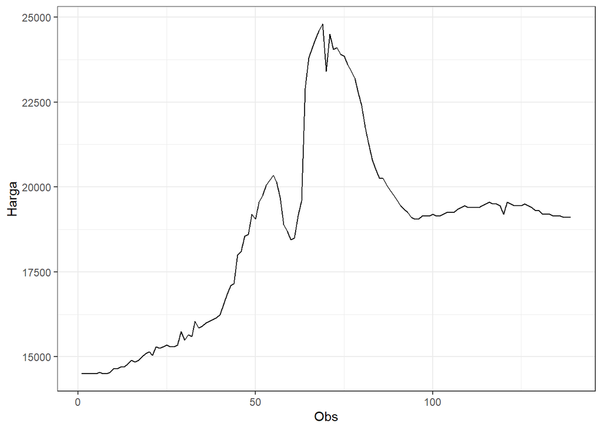

```r
plot_data.ts <- data.ts |> as_tsibble() |>
  ggplot(aes(x = index, y = value)) + geom_line() + theme_bw() +
  xlab("Obs") + ylab("Harga")
plot_data.ts
```

```r
mean(data.ts)
```

```
## [1] 18653.96
```

Plot deret waktu di atas menunjukkan bahwa data tidak stasioner dalam rataan, ditandai dengan data yang tidak menyebar di sekitar nilai tengahnya (18653.96).

### Plot ACF

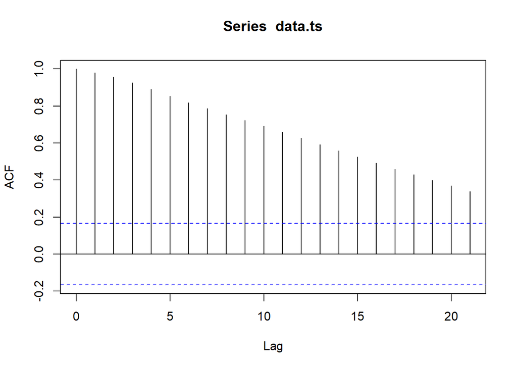

```r
acf(data.ts)
```

Berdasarkan plot ACF, terlihat bahwa plot ACF pada data tersebut cenderung *tails off slowly* yang berarti data tidak stasioner pada rataan.

### Uji ADF

```r
tseries::adf.test(data.ts)
```

```
##
##  Augmented Dickey-Fuller Test
##
## data:  data.ts
## Dickey-Fuller = -1.5194, Lag order = 5, p-value = 0.7765
## alternative hypothesis: stationary
```

$H_0$ : Data tidak stasioner dalam rataan

$H_1$ : Data stasioner dalam rataan

Berdasarkan uji ADF tersebut, didapat *p-value* sebesar 0.7765 yang lebih besar dari taraf nyata 5% sehingga tak tolak $H_0$ dan menandakan bahwa data tidak stasioner dalam rataan. Hal ini sesuai dengan hasil eksplorasi menggunakan plot time series dan plot ACF.

### Plot Box-Cox

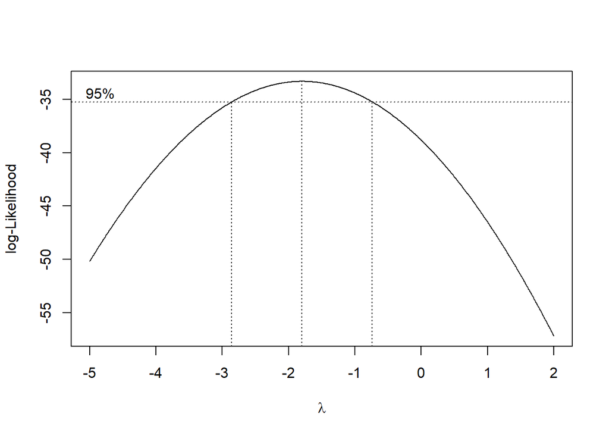

```r
index <- seq(1:139)
bc = boxcox(data.ts~index, lambda = seq(-5,2,by=0.01))
```

```r
#Nilai Rounded Lambda
lambda <- bc$x[which.max(bc$y)]
lambda
```

```
## [1] -1.8
```

```r
#SK
bc$x[bc$y > max(bc$y) - 1/2 * qchisq(.95,1)]
```

```
##   [1] -2.86 -2.85 -2.84 -2.83 -2.82 -2.81 -2.80 -2.79 -2.78 -2.77 -2.76 -2.75
##  [13] -2.74 -2.73 -2.72 -2.71 -2.70 -2.69 -2.68 -2.67 -2.66 -2.65 -2.64 -2.63
##  [25] -2.62 -2.61 -2.60 -2.59 -2.58 -2.57 -2.56 -2.55 -2.54 -2.53 -2.52 -2.51
##  [37] -2.50 -2.49 -2.48 -2.47 -2.46 -2.45 -2.44 -2.43 -2.42 -2.41 -2.40 -2.39
##  [49] -2.38 -2.37 -2.36 -2.35 -2.34 -2.33 -2.32 -2.31 -2.30 -2.29 -2.28 -2.27
##  [61] -2.26 -2.25 -2.24 -2.23 -2.22 -2.21 -2.20 -2.19 -2.18 -2.17 -2.16 -2.15
##  [73] -2.14 -2.13 -2.12 -2.11 -2.10 -2.09 -2.08 -2.07 -2.06 -2.05 -2.04 -2.03
##  [85] -2.02 -2.01 -2.00 -1.99 -1.98 -1.97 -1.96 -1.95 -1.94 -1.93 -1.92 -1.91
##  [97] -1.90 -1.89 -1.88 -1.87 -1.86 -1.85 -1.84 -1.83 -1.82 -1.81 -1.80 -1.79
## [109] -1.78 -1.77 -1.76 -1.75 -1.74 -1.73 -1.72 -1.71 -1.70 -1.69 -1.68 -1.67
## [121] -1.66 -1.65 -1.64 -1.63 -1.62 -1.61 -1.60 -1.59 -1.58 -1.57 -1.56 -1.55
## [133] -1.54 -1.53 -1.52 -1.51 -1.50 -1.49 -1.48 -1.47 -1.46 -1.45 -1.44 -1.43
## [145] -1.42 -1.41 -1.40 -1.39 -1.38 -1.37 -1.36 -1.35 -1.34 -1.33 -1.32 -1.31
## [157] -1.30 -1.29 -1.28 -1.27 -1.26 -1.25 -1.24 -1.23 -1.22 -1.21 -1.20 -1.19
## [169] -1.18 -1.17 -1.16 -1.15 -1.14 -1.13 -1.12 -1.11 -1.10 -1.09 -1.08 -1.07
## [181] -1.06 -1.05 -1.04 -1.03 -1.02 -1.01 -1.00 -0.99 -0.98 -0.97 -0.96 -0.95
## [193] -0.94 -0.93 -0.92 -0.91 -0.90 -0.89 -0.88 -0.87 -0.86 -0.85 -0.84 -0.83
## [205] -0.82 -0.81 -0.80 -0.79 -0.78 -0.77 -0.76 -0.75 -0.74
```

Gambar di atas menunjukkan nilai *rounded value* ($\lambda$) optimum sebesar **-1.8** dan pada selang kepercayaan 95% nilai memiliki batas bawah **-2.86** dan batas atas **-0.74**. Selang tersebut tidak memuat nilai satu sehingga dapat dikatakan bahwa data tidak stasioner dalam ragam.

### Bagian 1

```r
dt_data<- data.ts[1:90] |> ts()
mean(dt_data)
```

```
## [1] 18301.11
```

```r
var(dt_data)
```

```
## [1] 11192752
```

#### Plot Time Series

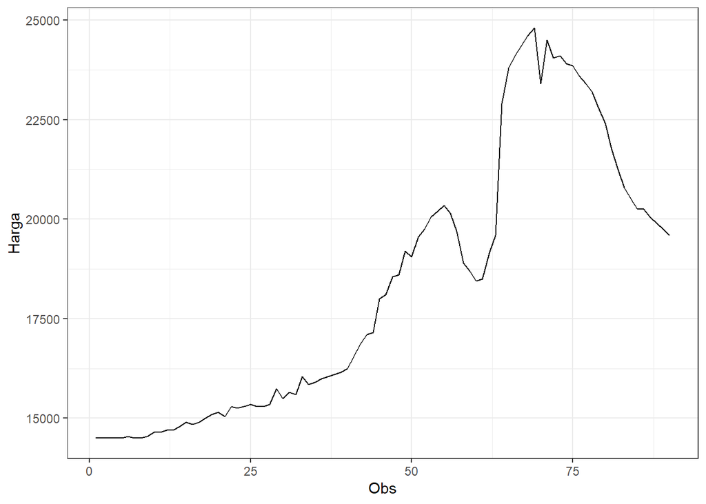

```r
dt_data |> as_tsibble() |>
  ggplot(aes(x = index, y = value)) +
  geom_line() + theme_bw() +
  xlab("Obs") + ylab("Harga")
```

```r
mean(dt_data)
```

```
## [1] 18301.11
```

Plot deret waktu di atas menunjukkan bahwa data tidak stasioner dalam rataan, ditandai dengan data yang tidak menyebar di nilai tengahnya (18301.11).

#### Plot ACF

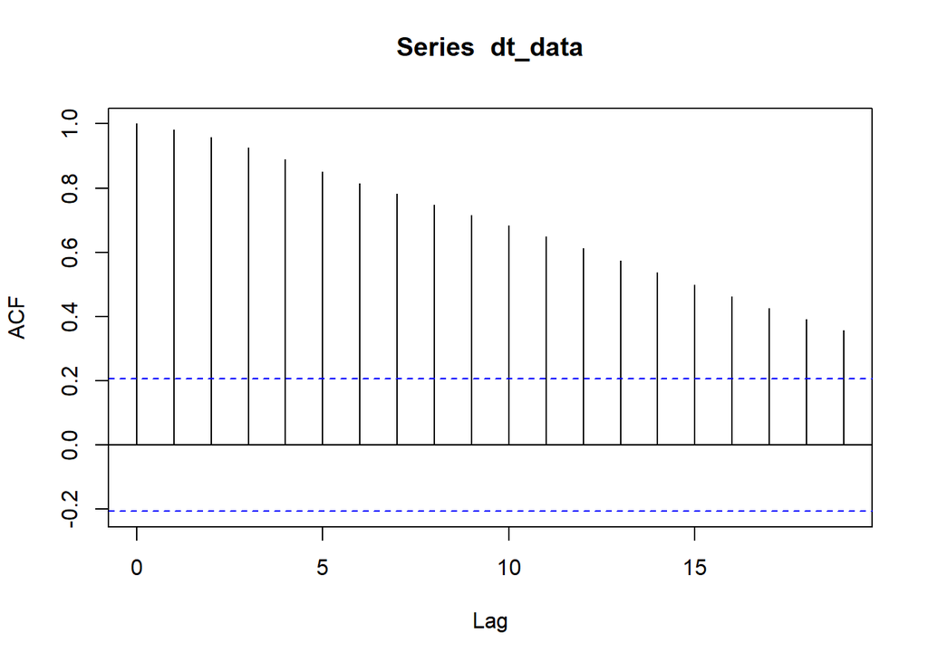

```r
acf(dt_data)
```

Berdasarkan plot ACF, terlihat bahwa plot ACF pada data tersebut cenderung *tails off slowly* sehingga bisa dikatakan data tidak stasioner dalam rataan.

#### Uji ADF

```r
tseries::adf.test(dt_data)
```

```
##
##  Augmented Dickey-Fuller Test
##
## data:  dt_data
## Dickey-Fuller = -2.0527, Lag order = 4, p-value = 0.5545
## alternative hypothesis: stationary
```

$H_0$ : Data tidak stasioner dalam rataan

$H_1$ : Data stasioner dalam rataan

Berdasarkan uji ADF tersebut, didapat *p-value* sebesar 0.5545 yang lebih besar dari taraf nyata 5% sehingga tak tolak $H_0$ dan menandakan bahwa data tidak stasioner dalam rataan. Hal ini sesuai dengan hasil eksplorasi menggunakan plot time series dan plot ACF.

#### Plot Boxcox

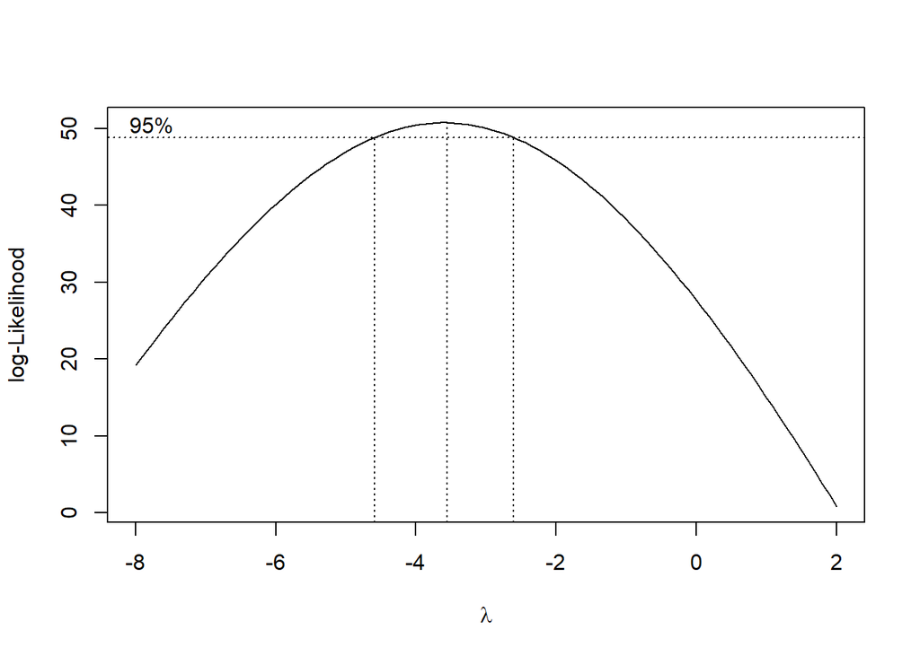

```r
index <- seq(1:90)
bc = boxcox(dt_data~index, lambda = seq(-8,2,by=1))
```

```r
#Nilai Rounded Lambda
lambda <- bc$x[which.max(bc$y)]
lambda
```

```
## [1] -3.555556
```

```r
#SK
bc$x[bc$y > max(bc$y) - 1/2 * qchisq(.95,1)]
```

```
##  [1] -4.565657 -4.464646 -4.363636 -4.262626 -4.161616 -4.060606 -3.959596
##  [8] -3.858586 -3.757576 -3.656566 -3.555556 -3.454545 -3.353535 -3.252525
## [15] -3.151515 -3.050505 -2.949495 -2.848485 -2.747475 -2.646465
```

Gambar di atas menunjukkan nilai *rounded value* ($\lambda$) optimum sebesar **-3.555556** dan pada selang kepercayaan 95% nilai memiliki batas bawah **-4.565657** dan batas atas **-2.646465**. Selang tersebut tidak memuat nilai satu sehingga dapat dikatakan bahwa data bangkitan tidak stasioner dalam ragam.

#### Bagian 2

```r
dt_data2 <- data.ts[91:139] |> ts()
mean(dt_data2)
```

```
## [1] 19302.04
```

```r
var(dt_data2)
```

```
## [1] 23016.58
```

#### Plot Time Series

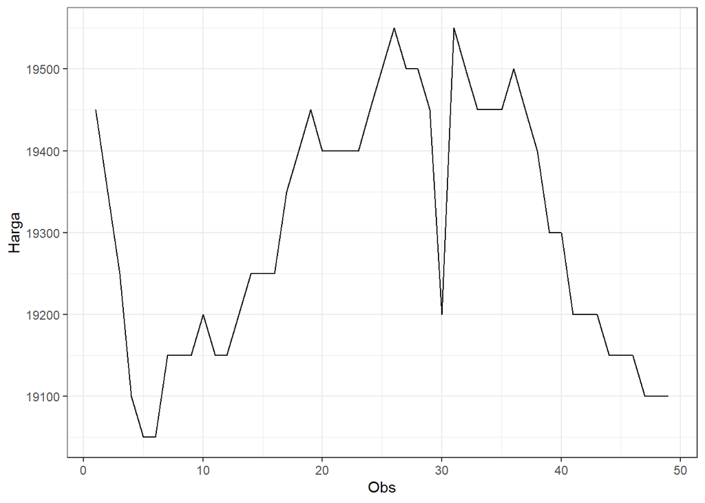

```r
dt_data2 |> as_tsibble() |>
  ggplot(aes(x = index, y = value)) +
  geom_line() + theme_bw() +
  xlab("Obs") + ylab("Harga")
```

```r
mean(dt_data2)
```

```
## [1] 19302.04
```

Plot deret waktu di atas menunjukkan bahwa data tidak stasioner dalam rataan, ditandai dengan data yang tidak menyebar di sekitar nilai tengahnya (19302.04).

#### Plot ACF

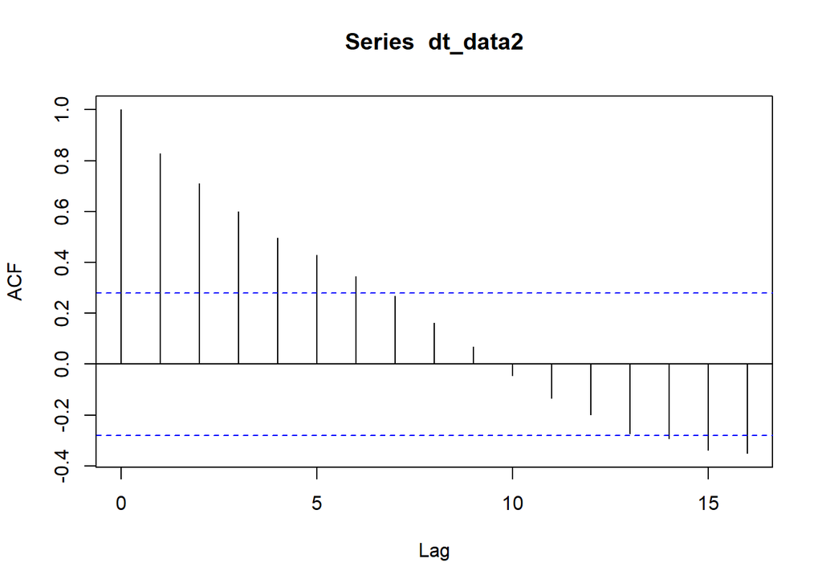

```r
acf(dt_data2)
```

Berdasarkan plot ACF, terlihat bahwa plot ACF pada data tersebut cenderung *tails off slowly* sehingga dapat dikatakan data tidak stasioner dalam rataan.

#### Uji ADF

```r
adf.test(dt_data2)
```

```
##
##  Augmented Dickey-Fuller Test
##
## data:  dt_data2
## Dickey-Fuller = -0.95679, Lag order = 3, p-value = 0.9356
## alternative hypothesis: stationary
```

$H_0$ : Data tidak stasioner dalam rataan

$H_1$ : Data stasioner dalam rataan

Berdasarkan uji ADF tersebut, didapat *p-value* sebesar 0.9356 yang lebih besar dari taraf nyata 5% sehingga tak tolak $H_0$ dan menandakan bahwa data tidak stasioner dalam rataan. Hal ini sesuai dengan hasil eksplorasi menggunakan plot time series dan plot ACF.

#### Plot Boxcox

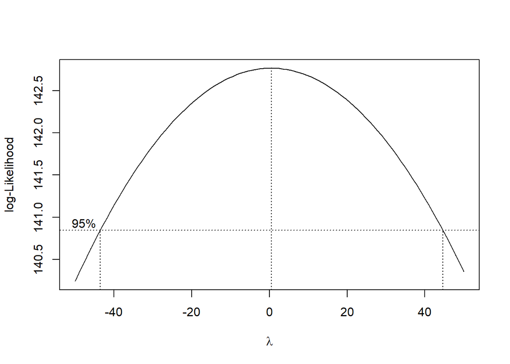

```r
index <- seq(91:139)
bc = boxcox(dt_data2~index, lambda = seq(-50,50,by=2))
```

```r
#Nilai Rounded Lambda
lambda <- bc$x[which.max(bc$y)]
lambda
```

```
## [1] 0.5050505
```

```r
#SK
bc$x[bc$y > max(bc$y) - 1/2 * qchisq(.95,1)]
```

```
##  [1] -42.9292929 -41.9191919 -40.9090909 -39.8989899 -38.8888889 -37.8787879
##  [7] -36.8686869 -35.8585859 -34.8484848 -33.8383838 -32.8282828 -31.8181818
## [13] -30.8080808 -29.7979798 -28.7878788 -27.7777778 -26.7676768 -25.7575758
## [19] -24.7474747 -23.7373737 -22.7272727 -21.7171717 -20.7070707 -19.6969697
## [25] -18.6868687 -17.6767677 -16.6666667 -15.6565657 -14.6464646 -13.6363636
## [31] -12.6262626 -11.6161616 -10.6060606  -9.5959596  -8.5858586  -7.5757576
## [37]  -6.5656566  -5.5555556  -4.5454545  -3.5353535  -2.5252525  -1.5151515
## [43]  -0.5050505   0.5050505   1.5151515   2.5252525   3.5353535   4.5454545
## [49]   5.5555556   6.5656566   7.5757576   8.5858586   9.5959596  10.6060606
## [55]  11.6161616  12.6262626  13.6363636  14.6464646  15.6565657  16.6666667
## [61]  17.6767677  18.6868687  19.6969697  20.7070707  21.7171717  22.7272727
## [67]  23.7373737  24.7474747  25.7575758  26.7676768  27.7777778  28.7878788
## [73]  29.7979798  30.8080808  31.8181818  32.8282828  33.8383838  34.8484848
## [79]  35.8585859  36.8686869  37.8787879  38.8888889  39.8989899  40.9090909
## [85]  41.9191919  42.9292929  43.9393939
```

Gambar di atas menunjukkan nilai *rounded value* ($\lambda$) optimum sebesar **0.5050505** dan pada selang kepercayaan 95% nilai memiliki batas bawah **-42.9292929** dan batas atas **43.9393939**. Selang tersebut memuat nilai satu sehingga dapat dikatakan bahwa data bangkitan stasioner dalam ragam.

### Kesimpulan

Dapat disimpulkan bahwa data keseluruhan tidak stasioner dalam rataan dan tidak stationer dalam ragam. Namun pada partisi data ke 2 dari data ke 90-139 data termasuk stasioner dalam ragam.